# Informe sobre Personas extranjeras privadas de libertad en el Norte de Chile

Quinteros, Daniel Núcleo de Estudios Criminológicos de la Frontera Universidad Arturo Prat

12 de abril de 2020

### 1. Personas extranjeras privadas de libertad en el Norte de Chile según nacionalidad: análisis regional

#### Gráfico 1.1 Cantidad de personas extranjeras privadas de libertad en el Norte de Chile por año y región, según nacionalidad

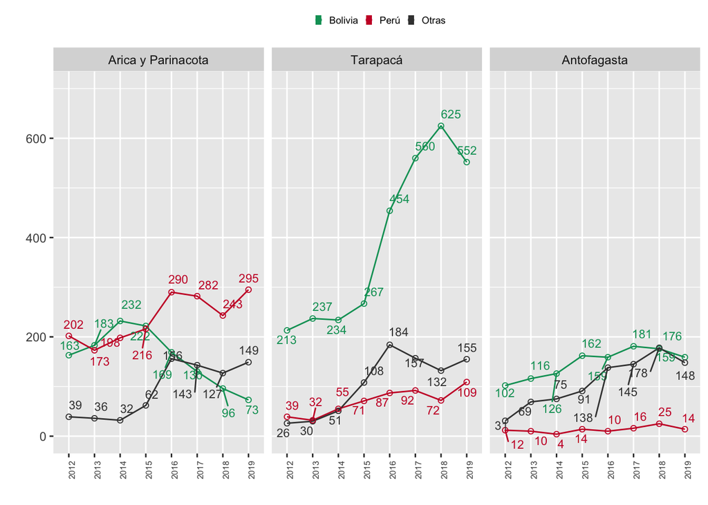

Como muestra el Gráfico 1.1, desde el año 2012 la cantidad de personas extranjeras privadas de libertad en el Norte Grande de Chile ha aumentado considerablemente en la última década. En la región de Arica y Parinacota, desde el año 2013 se observa un sostenido aumento de personas nacionales del Perú, una disminución de nacionales de Bolivia desde el 2014 en adelante y un brusco aumento, entre 2015 y 2016, de nacionales de otros países. La región de Tarapacá, por su parte, destaca por el aumento generalizado de personas extranjeras encarceladas, pero particularmente de nacionales de Bolivia quienes han duplicado su población penal entre los años 2015 y 2018. Por último, no obstante la región de Antofagasta muestra una menor cantidad de personas extranjeras privadas de libertad durante todo el período 2012-2019, llama la atención el sostenido aumento de nacionales de Bolivia y otras nacionalidades.

#### Gráfico 1.2 Proporción y cantidad de personas extranjeras privadas de libertad en el Norte de Chile por año y región, según nacionalidad

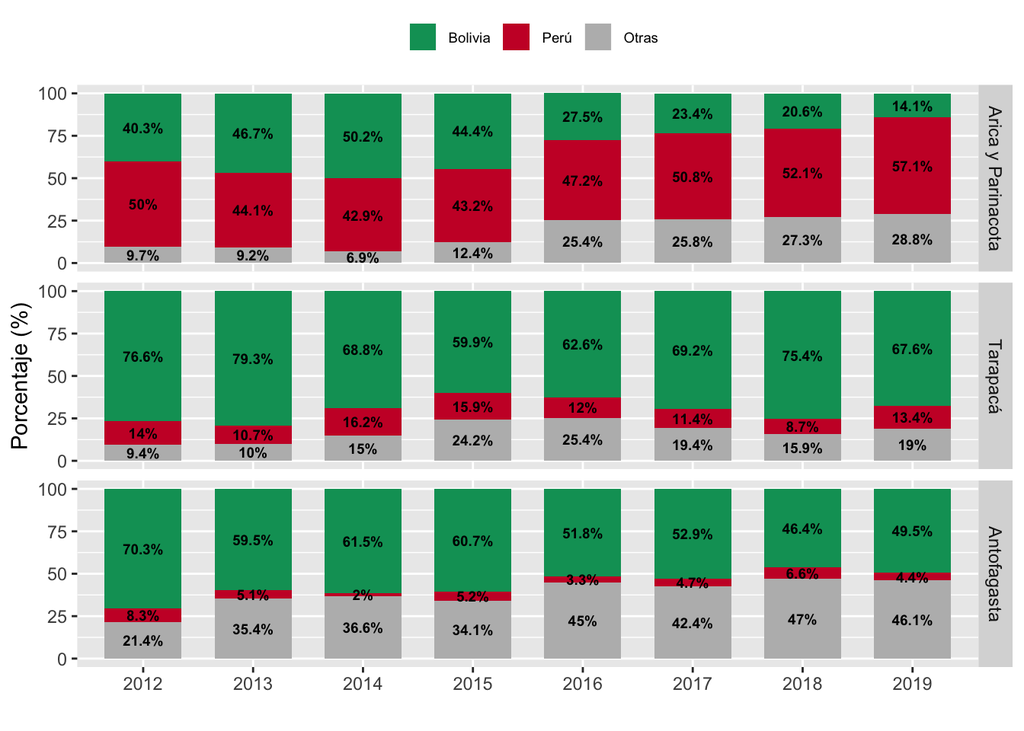

El Gráfico 1.2 permite complementar el análisis sobre el aumento de personas extranjeras encarceladas en el Norte Grande de Chile. En este sentido, destaca significativamente la proporción de nacionales de países fronterizos, quienes llegan a representar 6 de cada 10 en Arica y Parinacota, 8 de 10 en Tarapacá y 1 de cada 2 en Antofagasta. No obstante ello, puede observarse que a pesar del protagonismo de las y los nacionales de Bolivia y Perú en estas regiones, es posible advertir a la vez una proporción creciente de nacionales de otros países. De este modo, por ejemplo, mientras para el año 2012 1 de cada 10 personas extranjeras provenían de otros países distintos a Perú y Bolivia en Arica y Parinacota, ese porcentaje subió a 25,4% en 2016 y 28,8% en 2019. Misma situación se observa tanto en Tarapacá como en Antofagasta, donde las proporciones de otras nacionalidades no fronterizas han llegado a representar hasta un 25,4% en Tarapacá el año 2016 y un 47% en Antofagasta el 2018.

### 2. Personas extranjeras privadas de libertad en el Norte de Chile según nacionalidad: análisis por establecimiento

#### Gráfico 2.1 Cantidad de personas extranjeras privadas de libertad en el Norte de Chile por año y unidad, según nacionalidad

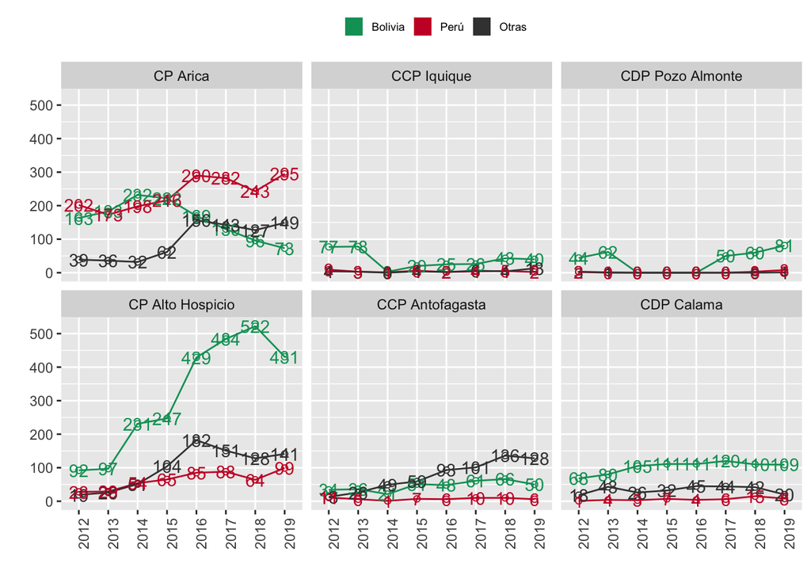

#### Gráfico 2.2 Proporción de personas extranjeras privadas de libertad en el Norte de Chile por año y unidad, según nacionalidad

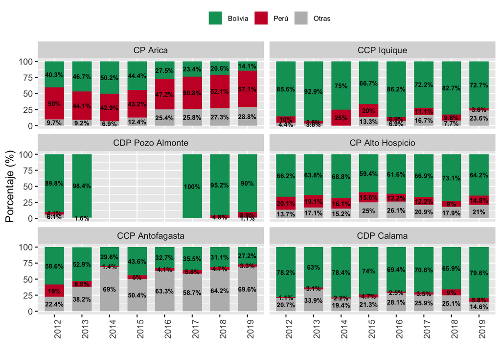

Lo señalado anteriormente se ve confirmado al revisar la evolución por cada recinto penitenciario que se presentan en los gráficos 2.1 y 2.2. En el caso del Complejo Penitenciario Arica (CP Arica), las cifras coinciden con lo exhibido a nivel regional, puesto que es el único centro penitenciario con régimen cerrado de relevancia en la región. Para el caso de Tarapacá, es posible advertir que el Centro de Cumplimiento Penitenciario de Iquique (CCP Iquique), exclusivo para mujeres, ha visto una disminución de su población extranjera desde el año 2014 a la fecha, pero siempre con una mayor proporción de bolivianas. Frente a ello contrasta el caso del Centro de Detención Preventiva de Pozo Almonte (CDP Pozo Almonte) que, tras su reapertura en 2017 luego del terremoto de 2014, ha exhibido un progresivo aumento de bolivianos cumpliendo prisión preventiva. Esta tendencia regional se observa con mayor claridad al revisar las cifras del CP Alto Hospicio, donde conviven hombres y mujeres con o sin condena, el que exhibe un aumento de hasta un 467% de personas bolivianas durante el período. Antofagasta, por su parte, cuenta con el CCP Antofagasta donde el aumento de personas extranjeras ha estado concentrado principalmente en nacionalidades no fronterizas, lo que contrasta con lo observado con el otro recinto de la región, CDP Calama, el que ha mantenido relativamente constante su cantidad de personas extranjeras, pero siempre con una mayor proporción de personas bolivianas.

### 3. Personas extranjeras privadas de libertad en el Norte de Chile al 31 de diciembre de 2019 según nacionalidad y sexo

#### Gráfico 3.1 Proporción y cantidad de personas extranjeras privadas de libertad en el Norte de Chile al 31 de diciembre de 2108 y 2019 según nacionalidad y sexo, por región

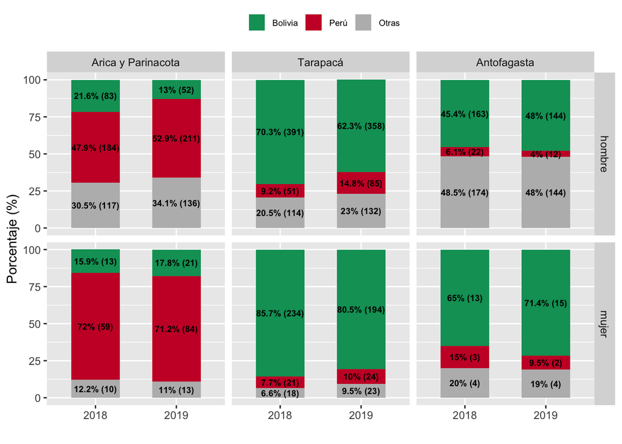

Para analizar las características de la población extranjera encarcelada en el Norte Grande de Chile, el Gráfico 3.1 presenta la proporción y cantidad de personas extranjeras privadas de libertad en cada región al día 31 de diciembre del año 2018 y 2019, por sexo y nacionalidad. En base a estos datos, es posible observar en primer lugar que, mientras 7 de cada 10 mujeres encarceladas en la región de Arica y Parinacota son peruanas, esa proporción se reduce al 52,9% para el caso de los hombres, grupo que exhibe una mayor presencia de nacionalidades no fronterizas. En segundo lugar, Tarapacá mantiene la sobrerrepresentación de personas bolivianas, pero con una marcada concentración en el caso de las mujeres. Resulta interesante observar, además, que las frecuencias absolutas y relativas de personas bolivianas se redujo entre el 2018 y eñ 2019, con aumentos relativos y absolutos de nacionales de Perú y de otras nacionalidades. Por último, el caso de Antofagasta muestra una mayor proporción de otras nacionalidades, especialmente en el caso de los hombres. Para el caso de las mujeres, las frecuencias absolutas y relativas de mujeres bolivianas representan alrededor de dos tercios, lo cual aumentó levemente entre 2018 y 2019.

#### Gráfico 3.2 Proporción y cantidad de personas extranjeras privadas de libertad en el Norte de Chile al 31 de diciembre de 2019 según nacionalidad y sexo, por establecimiento

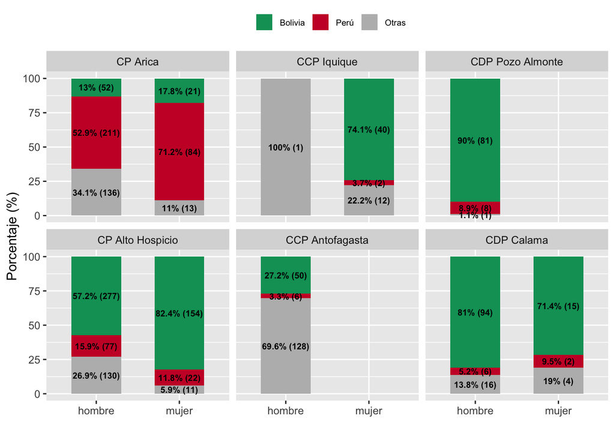

El análisis de las diferencias por sexo se confirma al revisar los datos que presenta el Gráfico 3.2 respecto de cada establecimiento penitenciario al día 31 de diciembre de 2019. El CP Arica muestra una mayor proporción de hombres y mujeres peruanas, con un mayor peso relativo de otras nacionalidades para el caso de los hombres. El CCP Iquique, por su parte, muestra que tres de cada cuatro extranjeras son bolivianes y, aunque no debería tener hombres en su interior, el registro oficial muestra a un hombre, lo cual puede deberse bien a un error de registro o a una excepción del régimen interno del establecimiento. En el caso del CDP Pozo Almonte, la sobrerrepresentación de bolivianos resulta evidente, en tanto 9 de cada 10 extranjeros son de dicho país. En este mismo sentido, los datos del CP Alto Hospicio muestran una exacerbada proporción de personas bolivianas, lo cual se profundiza significativamente en el caso de las mujeres. Luego, el CDP Calama muestra la misma tendencia, con una marcada concentración de personas bolivianas, particularmente entre los hombres extranjeros. En contraste a lo anterior, los datos del CCP Antofagasta dan cuenta de una excepción a la realidad observada en otros recintos, en tanto 7 de cada 10 hombres extranjeros son de otras nacionalidades, particularmente de Colombia (60,8%).

### 4. Personas extranjeras privadas de libertad en el Norte de Chile según año y calidad procesal

#### Gráfico 4.1 Cantidad de personas extranjeras privadas de libertad en el Norte de Chile según año y calidad procesal: análisis regional

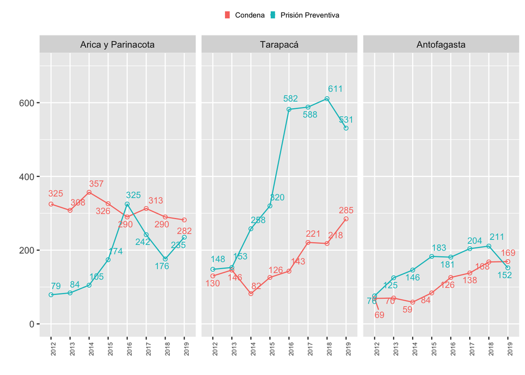

#### Gráfico 4.2 Cantidad de personas extranjeras privadas de libertad en el Norte de Chile por año, según calidad procesal: análisis regional por nacionalidad

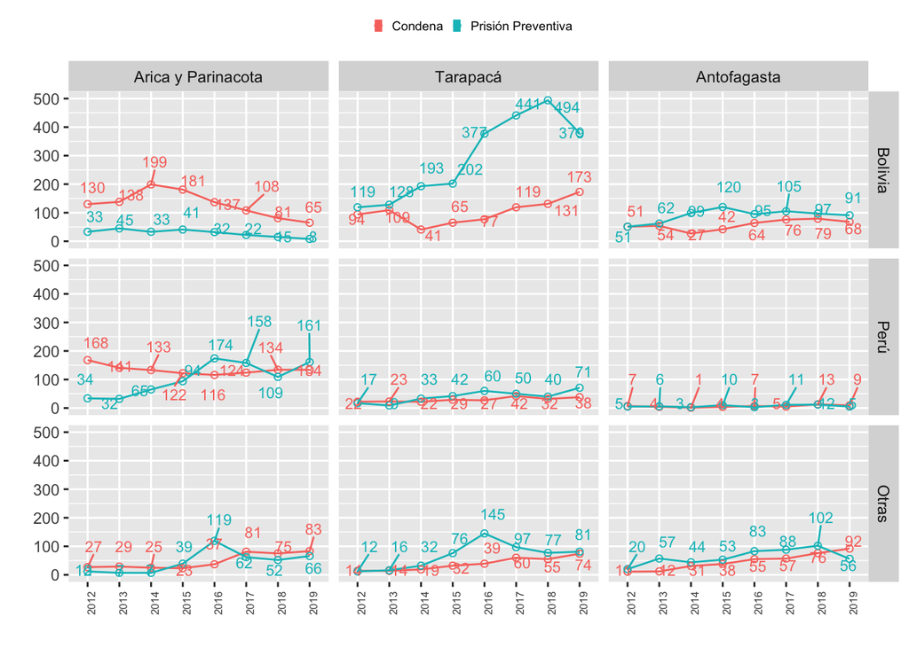

En línea con lo exhibido en el gráfico anterior, el Gráfico 4.2 muestra la evolución en la cantidad de personas extranjeras encarceladas según nacionalidad. De este modo es posible profundizar sobre la aplicación diferenciada de las prisiones preventivas según la nacionalidad de la persona en cada región. En primer lugar, los datos de Arica y Parinacota muestran que la baja en las condenas se debe principalmente a una disminución en la cantidad de personas bolivianas condenadas; a la inversa, el aumento de extranjeros/as en prisión preventiva se debe particularmente a la mayor cantidad de nacionales de Perú cumpliendo esta medida cautelar. En el caso de Tarapacá, el aumento de condenas y prisiones preventivas se explica especialmente por la mayor cantidad de personas bolivianas encarceladas, en cumplimiento de la medida cautelar a la espera de su sentencia. Por último, los aumentos de condenas y prisiones preventivas en Antofagasta se explican mayormente por el aumento de nacionales de bolivia y otros países en cualquiera de estas condiciones, mientras que los nacionales del Perú constituyen un grupo muy reducido durante todo el período.

#### Gráfico 4.3 Proporción y cantidad de personas extranjeras privadas de libertad en el Norte de Chile según nacionalidad y calidad procesal: análisis por establecimiento al 31 de diciembre de 2019

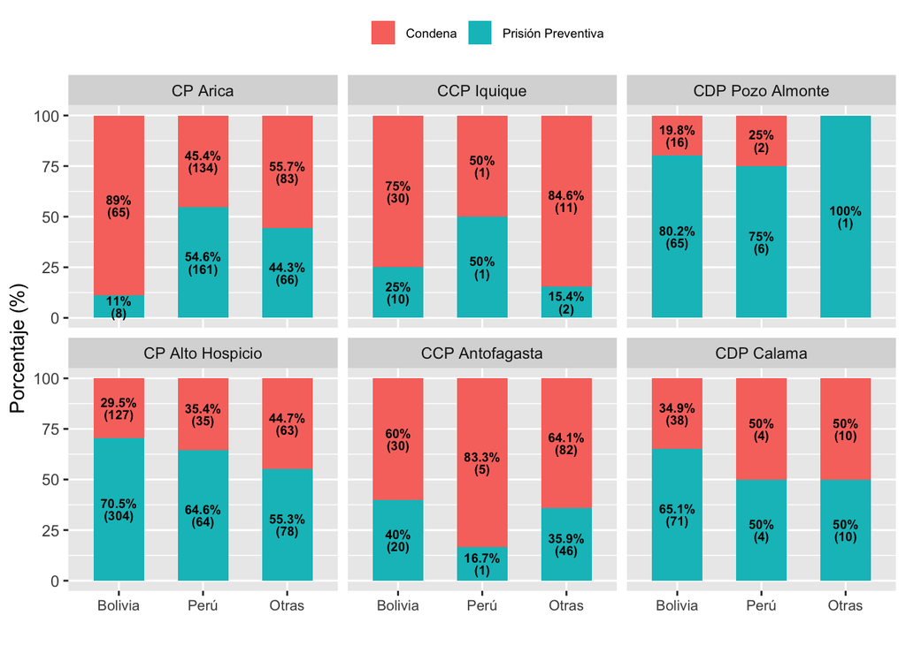

```r
ext19 <- ext %>% filter(Año=="2019")
df.calidadxañouni <- ext19 %>%
group_by(País,Calidad.Procesal,Unidad) %>%
summarise(n=sum(N)) %>%
group_by(País,Unidad) %>%
mutate(perc=100*n/sum(n))
df.calidadxañouni$perc <- round(df.calidadxañouni$perc, digits=1)
df.calidadxañouni$calidad <- ifelse(df.calidadxañouni$Calidad.Procesal=="Condenado","Condena","Prisión Preventiva")
df.calidadxañouni$perc[is.na(df.calidadxañouni$perc)] <- 0
df.calidadxañouni$País <- factor(df.calidadxañouni$País, levels=c("Bolivia", "Perú", "Otras"))

graf4.3.calidadxañouni <- ggplot(df.calidadxañouni,aes(x=factor(País), y=perc, fill=calidad))+
    geom_bar(position="stack", stat = "identity",  width = 0.6) +
    geom_text(data=df.calidadxañouni, aes(y=perc,label=ifelse(perc==0,"",paste0(perc,"%","\n(",n,")"))),
              position=position_stack(vjust = 0.5), size=2.5, fontface="bold", width = 0.1,lineheight = 0.8) +
  labs(  x="",
         y="Porcentaje (%)") +
  coord_cartesian(ylim = c(0, 100)) +
  theme(plot.title = element_text(size = 10, face = "bold", hjust = 0.5)) +
  theme(legend.position="top", legend.title = element_blank(), legend.text = element_text(size=7), legend.key.size = unit(1,"line"), axis.text.x = element_text(angle = 0, size=8)) +
  facet_wrap(~ factor(df.calidadxañouni$Unidad, levels = c("CP Arica", "CCP Iquique", "CDP Pozo Almonte", "CP Alto Hospicio", "CCP Antofagasta","CDP Calama")), nrow=2) +
  scale_fill_manual(values = c("Condena" = "#F8766D", "Prisión Preventiva" = "#00BFC4"))
graf4.3.calidadxañouni
```

El Gráfico 4.3 muestra las diferencias entre la calidad procesal de las personas encarceladas, para cada recinto penitenciario, según nacionalidad. De este modo es posible observar una mayor proporción de personas bolivianas condenadas en Arica y Parinacota (89%), mientras que para los nacionales de Perú y otros países, esta proporción baja a cerca de la mitad. En el CCP Iquique, mientras 3 de cada 4 bolivianas se encuentran condenadas, esa proporción aumenta al 85% para otros países, en tanto se registran sólo dos mujeres peruanas. En el CDP Pozo Almonte, debido a su carácter de centro de detención preventiva, la proporción de personas cumpliendo prisión preventiva supera el 75% para todas las nacionalidades, destacando el gran número de bolivianos en contraste con otras nacionalidades. En el CP Alto Hospicio se observa una gran cantidad y proporción de personas cumpliendo prisión preventiva, proporción que alcanza un 70,5% en el caso de nacionales de Bolivia, un 64,6% para nacionales de Perú y un 55,3% para otras nacionalidades. En la región de Antofagasta, el CCP muestra un alto porcentaje de condenas, en tanto 6 de cada 10 personas bolivianas o de otras nacionalidades se encuentra en esta situación, con una cifra más elevada para el caso de peruanos y peruanas, pero con una menor frecuencia absoluta. Por último, en el CDP Calama, los datos muestran que 2 de cada 3 nacionales de Bolivia se encuentra en prisión preventiva, proporción que se reduce a 1 de cada 2 para personas de Perú y otros países.

### 5. Personas extranjeras privadas de libertad en el Norte de Chile, según pertenencia étnica

#### Gráfico 5.1 Proporción y cantidad de personas privadas de libertad en el Norte Grande de Chile

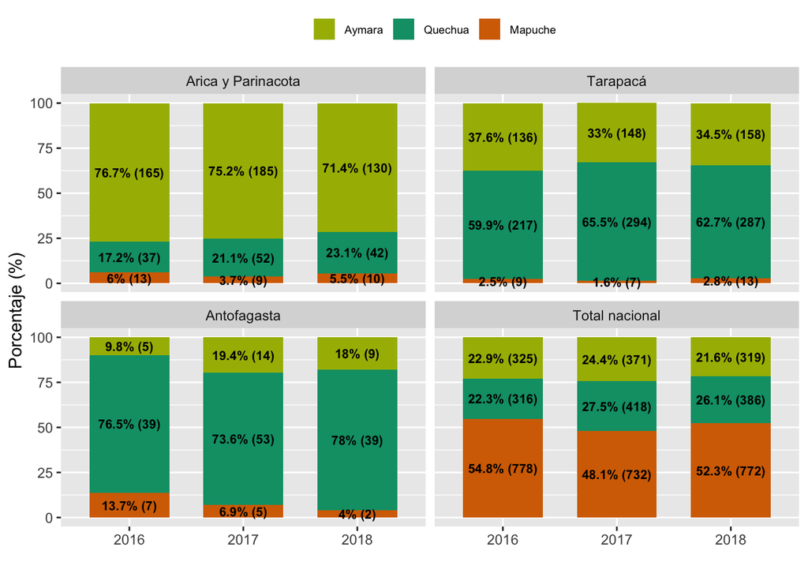

#### Gráfico 5.2

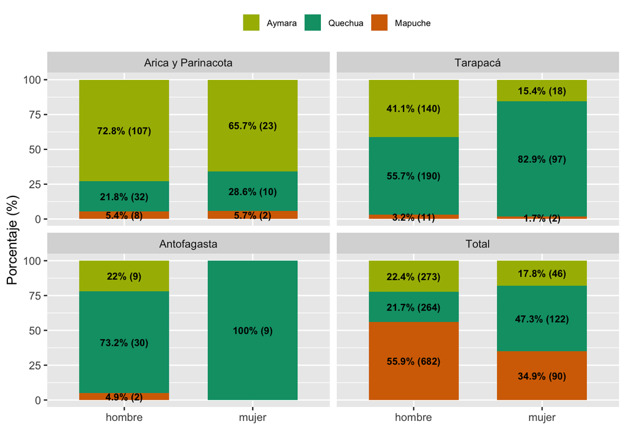